# Homework 9

Lawson Busch

11/15/2018

# Data and Libraries

Libraries:

```r
library(openintro)
library(dplyr)
library(randomForest)
library(rpart)
library(MASS)
library(ggplot2)
```

Data:

```r
set.seed(200)

data("email")
data("email_test")

# codebooks
?email

email <- email %>%
    mutate(spam = as.factor(spam)) %>%
    dplyr::select(-from, -viagra, -sent_email)
email_test <- email_test %>%
    mutate(spam = as.factor(spam)) %>%
    dplyr::select(-from, -viagra, -sent_email)
```

# Excercises

## Excercise 1

### 1a)

```r
dim(email)
```

```
## [1] 3921   18
```

```r
dim(email_test)
```

```
## [1] 1252   18
```

We have 3,921 training emails and 1,252 testing emails.

### 1b)

We have 17 possible predictors (we have 18 columns, but spam is our class, so we cannont use it as a predictor).

### 1c)

My priority would be increasing specificity for a spam filter. This is because misclassifying a non spam email as spam is a far worse outcome than misclassifying a spam email as non spam. The former could possibly have strong negative effects on someone’s life, while the later is just annoying.

## Excercise 2

First I will make a qda model using all possible predictors.

```r
qda_mod_all <- qda(spam ~ ., data = email)
qda_mod_all
```

```
## Call:
## qda(spam ~ ., data = email)
##
## Prior probabilities of groups:
##          0          1
## 0.90640143 0.09359857
##
## Group means:
##   to_multiple        cc       time       image    attach    dollar
## 0  0.17107485 0.4018008 1329298580 0.052898143 0.1240855 1.5433315
## 1  0.03269755 0.4305177 1329653285 0.005449591 0.2179837 0.7302452
##    winneryes    inherit   password  num_char line_breaks    format
## 0 0.01238042 0.03573438 0.11761396 11.250517    243.6531 0.7225661
## 1 0.05449591 0.05994550 0.01634877  5.439204    104.8202 0.4305177
##      re_subj exclaim_subj  urgent_subj exclaim_mess numbersmall numberbig
## 0 0.28615644   0.08019133 0.0008441193     6.508160   0.7481711 0.1392797
## 1 0.02179837   0.08174387 0.0108991826     7.321526   0.4577657 0.1362398
```

```r
qda_all_pred <- predict(qda_mod_all, email_test)$class
true <- email_test$spam
table(qda_all_pred, true)
```

```
##             true
## qda_all_pred   0   1
##            0 716  29
##            1 395 112
```

To calculate the specificity for this model:

```r
716 / (716 + 395)
```

```
## [1] 0.6444644
```

Or the specificity for this model is approximately 0.64, meaning that roughly 64% of non spam emails are correctly classified as not spam.

To calculate the sensitivity for this model:

```r
112 / (112 + 29)
```

```
## [1] 0.7943262
```

Or the sensitivity for this model is 0.79, meaning that roughly 79% of spam emails are correctly classified as spam.

The overall misclassification rate for this model is:

```r
mis <- (395 + 29) / nrow(email_test)
mis
```

```
## [1] 0.3386581
```

Or roughly 34% of the emails in our testing data set were misclassified.

This model has a good sensitivity but a very poor specificity, which is not what we want. Further, the overall misclassification rate is 1/3, which is pretty bad in this situation. To see if I can improve my qda model I will make a second qda model with some predictor selection. I will do this predictor selection by generating a random forest of 100 trees, and using the most important predictors from that forest.

To construct a 100 tree random forest:

```r
forest_R <- randomForest(spam ~ ., email, ntree = 100)

# arranged
data.frame(names = row.names(forest_R$importance), forest_R$importance) %>%
    arrange(desc(MeanDecreaseGini))
```

```
##           names MeanDecreaseGini
## 1      num_char       139.438823
## 2   line_breaks       113.984250
## 3          time        91.207238
## 4        number        40.320248
## 5  exclaim_mess        32.653233
## 6        dollar        28.996012
## 7       re_subj        20.206573
## 8        attach        18.090240
## 9        format        15.848244
## 10  to_multiple        15.281454
## 11       winner        10.578316
## 12      inherit         9.201586
## 13 exclaim_subj         7.642578
## 14           cc         7.632627
## 15  urgent_subj         4.125723
## 16     password         3.128285
## 17        image         1.266307
```

This above shows the most important predictors in the forest. I will use the first four predictors as that this the first point where the qda model begins to predict spam emails (not just classify everything as not spam).

```r
qda_mod_1 <- qda(spam ~ num_char + line_breaks + time + number, data = email) #The four most important predictors
qda_mod_1
```

```
## Call:
## qda(spam ~ num_char + line_breaks + time + number, data = email)
##
## Prior probabilities of groups:
##          0          1
## 0.90640143 0.09359857
##
## Group means:
##    num_char line_breaks       time numbersmall numberbig
## 0 11.250517    243.6531 1329298580   0.7481711 0.1392797
## 1  5.439204    104.8202 1329653285   0.4577657 0.1362398
```

```r
qda_1_pred <- predict(qda_mod_1, email_test)$class
true <- email_test$spam
table(qda_1_pred, true)
```

```
##           true
## qda_1_pred   0   1
##          0 994  92
##          1 117  49
```

To calculate the specificity for this model:

```r
994 / (994 + 117)
```

```
## [1] 0.8946895
```

Or the specificity for this model is approximately 0.89, meaning that roughly 89% of non spam emails are correctly classified as not spam.

To calculate the sensitivity for this model:

```r
49 / (49 + 92)
```

```
## [1] 0.3475177
```

Or the sensitivity for this model is 0.35, meaning that roughly 35% of spam emails are correctly classified as spam.

The overall misclassification rate for this model is:

```r
mis <- (117 + 92) / nrow(email_test)
mis
```

```
## [1] 0.1669329
```

Or roughly 16% of the emails in our testing data set were misclassified.

This pruned model is much better, as the specificity increased to 0.89 from 0.64 and the overall misclassification rate dropped to 16%, which is significantly lower than the prior model’s 34% misclassification rate. This does however come at the cost of sensitivity, which drops to 0.35 from 0.79.

However, the model’s overall accuracy is still not to my liking, so I decided to investigate. I looked at the predictors in the email data set, and it turns out many of them do not meet the qda assumtions because the predictors are not normally distributed around a mean value. This could explain the qda’s model iffy performance. For example, I made a density plot of the num_char variable below, where you can clearly see that data is not normally distributed.

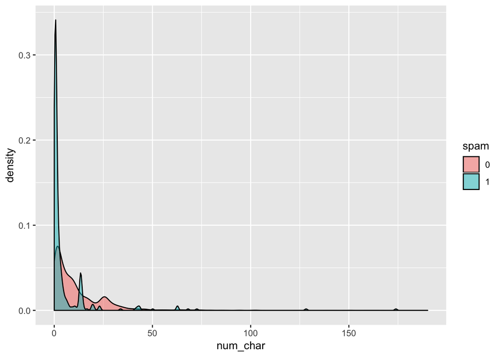

```r
ggplot(email, aes(x=num_char, fill = spam)) + geom_density(alpha=0.5)
```

In summary, I made two qda models. The first used all predictors, and had a specificity of 0.64, a sensitivity of 0.79, and an overall misclassification rate of 34%. I did not think this was good enough, as the specificity was very low and the misclassification rate was too high. I then did predictor selection using a random forest with 100 trees. This helped, as the specificity increased to 0.89, and the overall misclassification rate dropped to 16%. This came at the consequence of dropped sensitivity, as it decreased to 0.34. This is much better, but still not great so I looked at the predictors, and found that many of them did not meet the assumption of normality, which could explain the poor performance.

## Excercise 3

To begin we will first construct a tree using all possible predictors, and then plot it’s cp value (which is its node purity). This will allow me to select the most appropriate cp value, and thus decide how much to prune my tree.

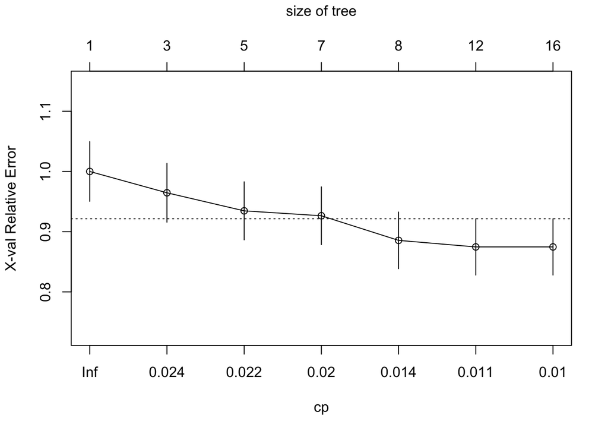

```r
tree_big <- rpart(spam ~ ., email)
plotcp(tree_big)
```

```r
printcp(tree_big)
```

```
##
## Classification tree:
## rpart(formula = spam ~ ., data = email)
##
## Variables actually used in tree construction:
## [1] attach      dollar      line_breaks num_char    number      re_subj
## [7] time        winner
##
## Root node error: 367/3921 = 0.093599
##
## n= 3921
##
##         CP nsplit rel error  xerror     xstd
## 1 0.024523      0   1.00000 1.00000 0.049697
## 2 0.023161      2   0.95095 0.96458 0.048898
## 3 0.020436      4   0.90463 0.93460 0.048206
## 4 0.019074      6   0.86376 0.92643 0.048015
## 5 0.010899      7   0.84469 0.88556 0.047042
## 6 0.010218     11   0.80109 0.87466 0.046778
## 7 0.010000     15   0.76022 0.87466 0.046778
```

From the above, we can see that we should use a cp value of 0.014, as that is the first cp value under one standard error. This cp value will give us the optimally pruned tree, which should have 8 breaks.

Below is the optimally pruned tree:

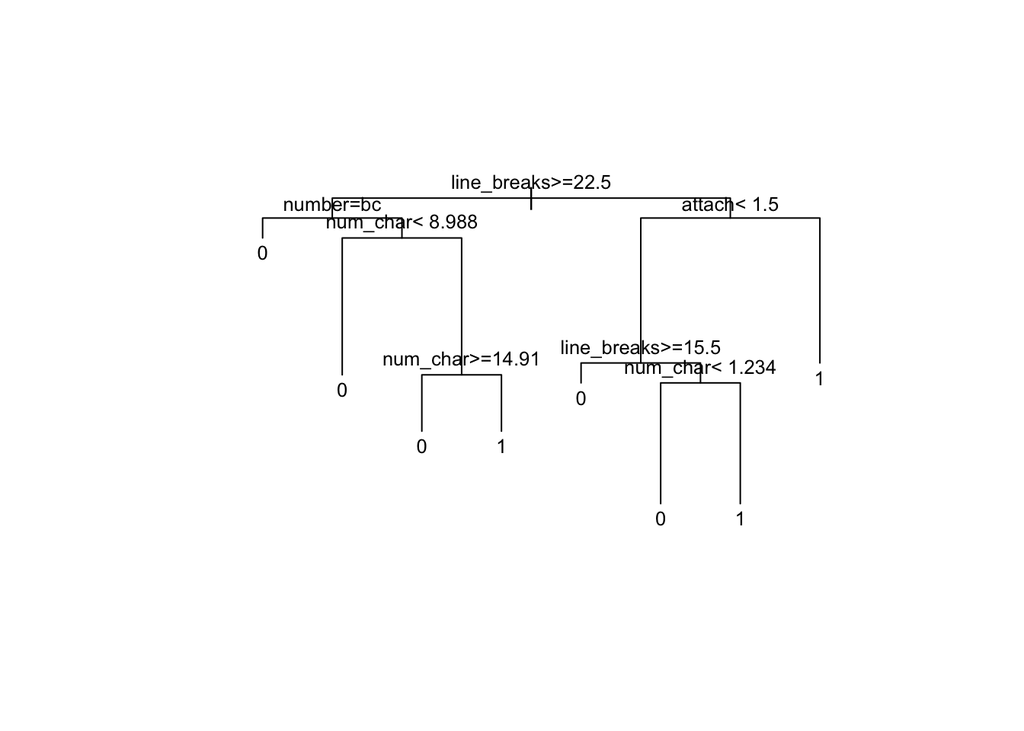

```r
tree_prune <- rpart(spam ~., email, cp = 0.014)
plot(tree_prune, margin = 0.2)
text(tree_prune, cex = 0.8)
```

```r
pred_tree_prune <- predict(tree_prune, newdata = email_test, type = "class")
true <- email_test$spam

table(pred_tree_prune, true)
```

```
##                true
## pred_tree_prune    0    1
##               0 1108  136
##               1    3    5
```

To calculate the specificity for this model:

```r
1108 / (1108 + 3)
```

```
## [1] 0.9972997
```

Or the specificity for this model is approximately 0.99, meaning that roughly 99% of non spam emails are correctly classified as not spam.

To calculate the sensitivity for this model:

```r
5 / (135 + 5)
```

```
## [1] 0.03571429
```

Or the sensitivity for this model is 0.035, meaning that roughly 3.5% of spam emails are correctly classified as spam.

The overall misclassification rate for this model is:

```r
mis <- (3 + 136) / nrow(email_test)
mis
```

```
## [1] 0.1110224
```

Or roughly 11% of the emails in our testing data set were misclassified.

In summary, I used the cp parameter to prune the tree down to a level where node purity would not improve much with further pruning. I then used the constructed tree to classify all the emails in our test data set. This classification had a specificity of 0.99, a sensitivity of 0.035, and an overall misclassification rate of 11%. However, it should also be noted that almost no emails (only 8) were actually classified as spam using this model.

## Excercise 4

To construct a random forest of 100 trees using all predictors in R:

```r
# obtain a forest
forest_all <- randomForest(spam ~ ., email, ntree = 100)

forest_pred <- predict(forest_all, email_test, type = "class")
true <- email_test$spam
table(forest_pred, true)
```

```
##            true
## forest_pred    0    1
##           0 1090   74
##           1   21   67
```

To calculate the specificity for this model:

```r
1089 / (1089 + 22)
```

```
## [1] 0.980198
```

Or the specificity for this model is approximately 0.98, meaning that roughly 98% of non spam emails are correctly classified as not spam.

To calculate the sensitivity for this model:

```r
69 / (69 + 72)
```

```
## [1] 0.4893617
```

The overall misclassification rate for this model is:

```r
mis <- (22 + 72) / nrow(email_test)
mis
```

```
## [1] 0.07507987
```

Or roughly 7.5% of the emails in our testing data set were misclassified.

## Excercise 5

### 5a

The qda classification tool performed the worst by far. It had the lowest specificity, at 0.89, (my most important metric) and highest overall misclassification rate at 16%. This is likely due to the predictors in the email data set not meeting the qda assumption of being normally distributed around a mean.

### 5b)

The most important predictors to the tree model are:

```r
# arranged
data.frame(names = row.names(forest_all$importance), forest_all$importance) %>%
    arrange(desc(MeanDecreaseGini))
```

```
##           names MeanDecreaseGini
## 1      num_char       132.050151
## 2   line_breaks       118.746884
## 3          time        87.002523
## 4        number        40.092963
## 5  exclaim_mess        34.077983
## 6        dollar        28.650976
## 7        attach        19.567252
## 8       re_subj        19.486747
## 9   to_multiple        15.498684
## 10       format        14.458362
## 11       winner        11.079544
## 12      inherit        10.119891
## 13           cc         7.838240
## 14 exclaim_subj         7.653847
## 15  urgent_subj         4.094838
## 16     password         3.628844
## 17        image         1.031867
```

Or we can see that the five most important predictors for my forest model are num_char, line_breaks, time, number, and exlaim_mess.